# adverse COVID-19 scenario setting slides

## adverse COVID-19 scenario

### Complexity of life

- genome sequences sizes:
  - human - billions
  - bacteria - millions
  - viruses - tens of thousands

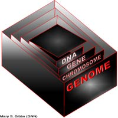

### What is the coronavirus?

- COVID-19 is of the coronaviridae family of RNA viruses, which include viruses such as Common cold, SARS, MERS, etc

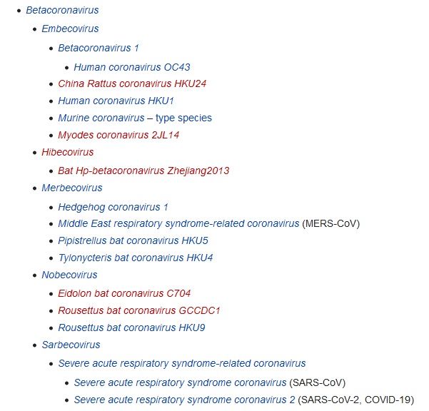

  (https://en.wikipedia.org/wiki/Coronaviridae)

### What is RNA?

- DNA vs RNA
  - DNA - ATGC - double stranded and transcripted to mRNA
  - RNA - AUGC - normally single stranded and translated to protein or reverse transcripted to DNA
- RNA genomes
  - Like DNA, RNA can carry genetic information. RNA viruses have genomes composed of RNA that encodes a number of proteins. The viral genome is replicated by some of those proteins, while other proteins protect the genome as the virus particle moves to a new host cell. (https://en.wikipedia.org/wiki/RNA)

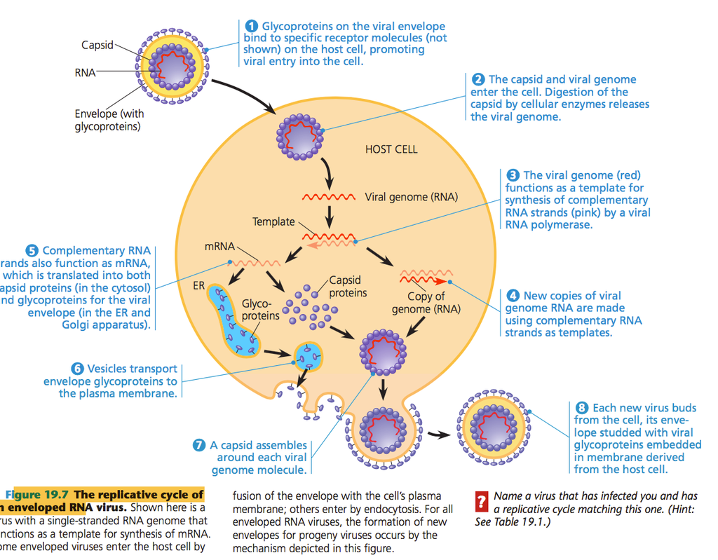

(https://biology.stackexchange.com/questions/54966/question-about-enveloped-rna-virus-viral-genome)

### What is being done in the current pandemic?

- WGS is being used at a global scale for epidemilogical surveillence, potentially allowing for prompt 'real time' response
- GISAID - german government initiated program: https://www.gisaid.org/epiflu-applications/next-hcov-19-app/
- COG-UK - UK focused program: https://microreact.org/project/cogconsortium-2020-06-05/

### How is it done?

- multiple sequence alignment

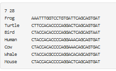

- phylogenetic trees

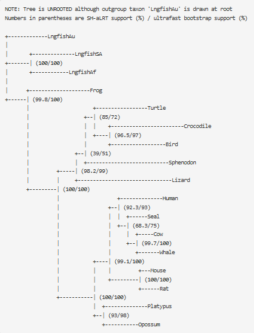

- pipelines specifically built for COVID-19 WGS - https://github.com/roblanf/sarscov2phylo/
- pipelines for obtaining lineages - https://pangolin.cog-uk.io/ (https://github.com/hCoV-2019/pangolin) - https://www.biorxiv.org/content/10.1101/2020.04.17.046086v1.full

### potential threats of modified viruses

- modifying viruses to be more virulent strains
- modifying viruses to be from different locations